# 民調的 ±3% 從哪裡來？

Week 04 第二段 · 以台北市長選舉民調為例

HT3001B 生物統計學與 R

2026/10/01

## 上週的數字：±3.0% 是怎麼算出來的？

2026 年 9 月中的一項電話民調訪問了 1,076 位設籍台北市、年滿 20 歲的民眾。

| 報導的數字 | 內容 |
| --- | --- |
| 支持度 | 蔣萬安 41.7%、沈伯洋 40.5%，差 1.2 個百分點 |
| 抽樣誤差 | 最大值 ±3.0%，95% 信心水準 |

這個 ±3.0% 是怎麼算出來的？它能不能用來判斷 1.2 個百分點的差距？

信民協會／戴立安民調（2026-09-16–18），依 2026-09-22 報導轉述 · Week 03 案例

## 同一套抽樣重複 1,000 次

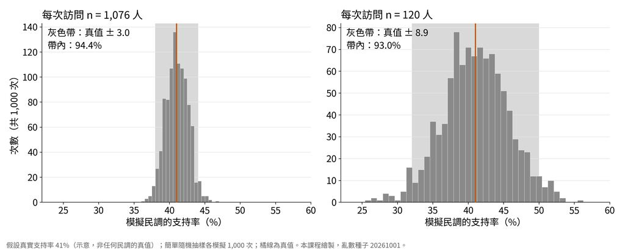

每一次模擬都是一份「可能發生的民調」：真值固定，樣本比例每次不同。這 1,000 個樣本比例的分布，稱為抽樣分布（sampling distribution）。n 從 1,076 降到 120，分布寬了多少？

抽樣分布的標準差稱為標準誤（standard error, SE）：這次模擬中，n ＝ 1,076 時約 1.6 個百分點，n ＝ 120 時約 4.7 個百分點。

IMS §13.1 Central Limit Theorem 概念 · 本課程模擬（真值假設為 41%，示意用）；本課程自製圖

## 標準誤與誤差範圍的公式

| 步驟 | 公式 |
| --- | --- |
| 一個比例的標準誤 | SE ＝ √[ p(1 − p) ／ n ] |
| 95% 誤差範圍（margin of error） | 1.96 × SE |
| 不知道 p 時取 p ＝ 0.5，得到最大誤差 | 1.96 × 0.5 ／ √n ≈ 0.98 ／ √n |

1.96 來自常態分布：約 95% 的樣本比例會落在真值 ±1.96 個標準誤之內。p(1 − p) 在 p ＝ 0.5 時最大，所以報導常寫「最大誤差」。

標準誤 誤差範圍 信心水準（confidence level）

IMS §13.3.2 Standard error、§13.3.3 Margin of error · §16.2.2 Standard error of one proportion

## 練習：驗算三份民調的誤差

用 0.98 ／ √n 驗算，報導的數字對得上嗎？

| 民調 | n | 0.98 ／ √n | 報導 |
| --- | --- | --- | --- |
| 信民協會（2026 年 9 月） | 1,076 | ±2.99% | ±3.0% |
| TVBS（2026 年 5 月） | 901 | ±3.27% | ±3.3% |
| TPOC（2026 年 8 月） | 1,099 | ±2.96% | ±2.96% |

三份都對得上。台北市有兩百多萬人，但誤差幾乎只由 n 決定；母群體遠大於樣本時，母群體大小的影響可以忽略。

三項民調的 n 與誤差依報導轉述，來源見 Week 03 assets 來源紀錄 · 驗算為本課程計算

## 樣本數要多少？

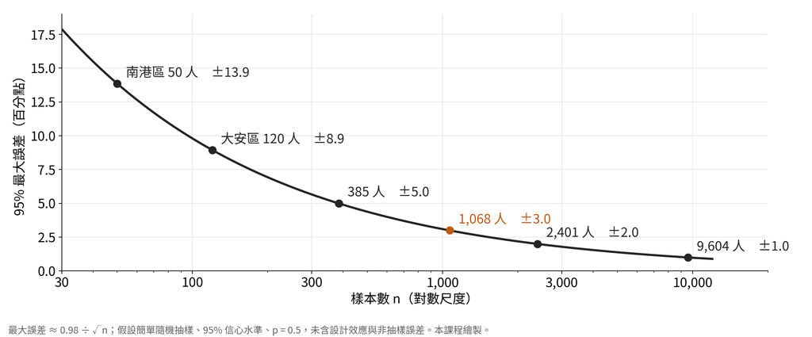

把公式反過來解：n ≈ 0.96 ／ E²。±5% 需要 385 人，±3% 需要 1,068 人，±2% 需要 2,401 人，±1% 需要 9,604 人。誤差要減半，樣本數要變四倍。

IMS §13.3.3 Margin of error 概念應用 · 假設簡單隨機抽樣、95% 信心水準、p ＝ 0.5；本課程自製圖

## 練習：行政區的樣本夠嗎？

1. 大安區 120 人、南港區 50 人，最大誤差各約多少？ 2. 若要 12 個行政區各自達到 ±5%，總共要訪問多少人？
1. 0.98 ／ √120 ≈ ±8.9 個百分點；0.98 ／ √50 ≈ ±13.9 個百分點。 2. 每區約 385 人，12 區約 4,620 人，是原本 1,076 人的四倍多。

全體的 ±3% 不能套用到子樣本：12 區的排序可以看，逐區的勝負不能下結論。

各區樣本數依 2026-09-22 報導轉述 · 本課程計算

## ±3% 不是差距的誤差

兩位候選人的比例來自同一批受訪者：一方多一點，另一方往往就少一點，差距的變異比單一比例大。

| 項目 | 數值 |
| --- | --- |
| 差距的標準誤 | SE(p̂₁ − p̂₂) ＝ √{ [p₁ + p₂ − (p₁ − p₂)²] ／ n } |
| 代入 0.417、0.405、n ＝ 1,076 | SE ≈ 2.76 個百分點 |
| 95% 誤差範圍 | 1.96 × 2.76 ≈ ±5.4 個百分點 |

差距 1.2 個百分點遠小於 ±5.4：這份民調不足以分辨兩人誰領先。拿差距和單一比例的 ±3% 相比，比錯了對象。

本課程補充：同一樣本中兩個比例之差的標準誤（多項分布），IMS §13.3 概念延伸 · 本課程計算

## 公式沒有算進去的

| 來源 | 對誤差的影響 |
| --- | --- |
| 分層與加權 | 有效樣本數通常小於完訪數，實際誤差略大於報導值（設計效應，design effect） |
| 拒訪、未回應 | 回應者與未回應者不同時產生偏差，不隨 n 縮小 |
| 抽樣底冊：只打市話或加手機 | 沒有機會被抽到的人造成偏差 |
| 題目措辭、未表態的處理 | 測量與分母不同造成偏差 |

±3% 只描述「隨機抽到哪些人」帶來的變異。上週第一段談的偏差，都不在這個數字裡。

IMS §13.3 概念應用 · Week 03 第一段（抽樣、未回應與抽樣底冊）

## 本週要回答的問題

1. 抽樣分布長什麼樣子？為什麼常接近常態？中央極限定理（central limit theorem）
2. 手上只有一份樣本時，怎麼估計標準誤？bootstrap 重抽樣
3. 誤差範圍與信賴區間（confidence interval）該怎麼解讀？

先用模擬看見重複抽樣的變異，再用公式與重抽樣估計它。

IMS Ch. 12–13 · 課綱第 4 週：用模擬觀察重複抽樣造成的變異